# Final Project

Niko Carvajal Janke

2025-05-13

### Dataset Selection

The dataset I chose is called **Students’ Social Media Addiction** and can be accessed here: https://www.kaggle.com/datasets/adilshamim8/social-media-addiction-vs-relationships/data

## Goals for Regression & Exploratory Data Analysis

I am interested in determining if I can build a model to identify if certain student lifestyle variables will significantly impact the average daily usage hours of screen time of that individual. Specifically, I aim to evaluate the influence of factors such as Age, Gender, Academic Level, Country, Most Used Social Media Platform, Sleep Hours Per Night, Relationship Status, Frequency of Conflicts over Social Media, and self-reported metrics including Social Media Addiction Score, Mental Health Score, and if Social Media Affects Academic Performance (Yes/No).

Below is the first series of steps, where I download the dataset of interest, complete **summary statistics of variables, Visualization of distributions and relationships, Identification of missing values and outliers,** and **Clean and preprocess the data.**

```r
#Load all the relevant packages for this project
library(skimr)
library(tidyverse)
library(car)
library(leaps)
library(glmnet)
library(lmtest)
library(lme4)
library(sandwich)
library(clubSandwich)
```

```r
#import dataset
rawdata <- read_csv("./archive/socialmedia.csv")
#summary statistics of variables | no missing values
skim(rawdata)
```

Data summary

| Name | rawdata |
| --- | --- |
| Number of rows | 705 |
| Number of columns | 13 |
| _______________________ |  |
| Column type frequency: |  |
| character | 6 |
| numeric | 7 |
| ________________________ |  |
| Group variables | None |

**Variable type: character**

| skim_variable | n_missing | complete_rate | min | max | empty | n_unique | whitespace |
| --- | --- | --- | --- | --- | --- | --- | --- |
| Gender | 0 | 1 | 4 | 6 | 0 | 2 | 0 |
| Academic_Level | 0 | 1 | 8 | 13 | 0 | 3 | 0 |
| Country | 0 | 1 | 2 | 15 | 0 | 110 | 0 |
| Most_Used_Platform | 0 | 1 | 4 | 9 | 0 | 12 | 0 |
| Affects_Academic_Performance | 0 | 1 | 2 | 3 | 0 | 2 | 0 |
| Relationship_Status | 0 | 1 | 6 | 15 | 0 | 3 | 0 |

**Variable type: numeric**

| skim_variable | n_missing | complete_rate | mean | sd | p0 | p25 | p50 | p75 | p100 | hist |
| --- | --- | --- | --- | --- | --- | --- | --- | --- | --- | --- |
| Student_ID | 0 | 1 | 353.00 | 203.66 | 1.0 | 177.0 | 353.0 | 529.0 | 705.0 | ▇▇▇▇▇ |
| Age | 0 | 1 | 20.66 | 1.40 | 18.0 | 19.0 | 21.0 | 22.0 | 24.0 | ▇▇▇▆▃ |
| Avg_Daily_Usage_Hours | 0 | 1 | 4.92 | 1.26 | 1.5 | 4.1 | 4.8 | 5.8 | 8.5 | ▁▆▇▅▁ |
| Sleep_Hours_Per_Night | 0 | 1 | 6.87 | 1.13 | 3.8 | 6.0 | 6.9 | 7.7 | 9.6 | ▁▆▇▇▂ |
| Mental_Health_Score | 0 | 1 | 6.23 | 1.11 | 4.0 | 5.0 | 6.0 | 7.0 | 9.0 | ▇▇▆▃▁ |
| Conflicts_Over_Social_Media | 0 | 1 | 2.85 | 0.96 | 0.0 | 2.0 | 3.0 | 4.0 | 5.0 | ▂▆▇▅▁ |
| Addicted_Score | 0 | 1 | 6.44 | 1.59 | 2.0 | 5.0 | 7.0 | 8.0 | 9.0 | ▁▃▇▇▇ |

```r
#checking for duplicate values
table(rawdata$Student_ID)[table(rawdata$Student_ID) > 1]
```

```
## named integer(0)
```

```r
#Removing StudentID since it is redundant
rawdata<-rawdata%>%
  select(!Student_ID)
```

### Visualizing Predictors

Next I visualize each of the predictor variables to get a sense of distributions that may be a problem later on if not addressed. While variables like sleep hours looks abnormal, the continuous and discrete data look ok besides that. We will see how the assumptions fair. The categorical variables look ok.

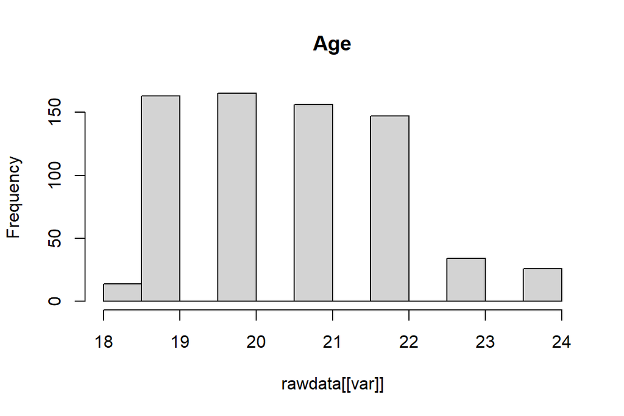

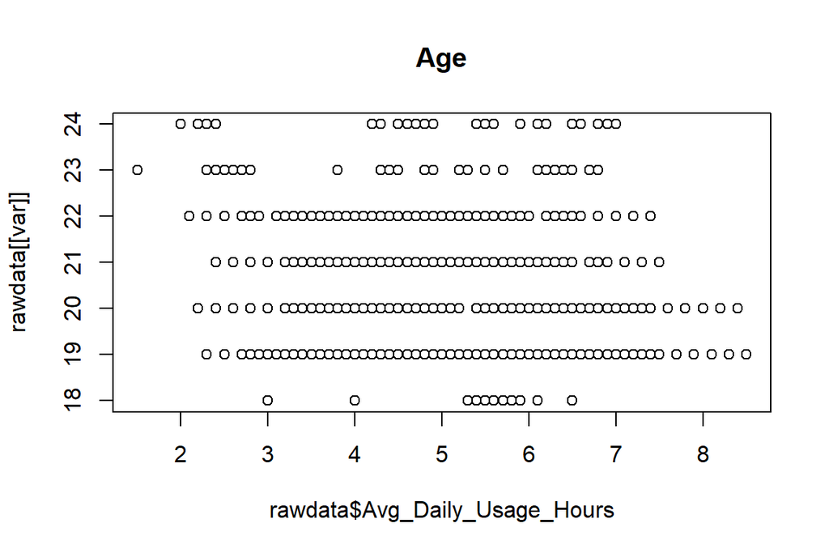

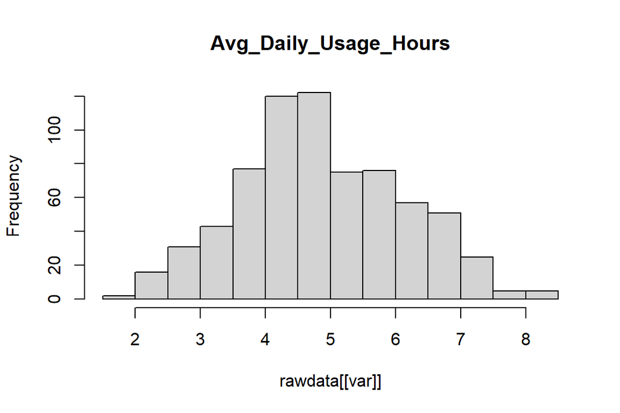

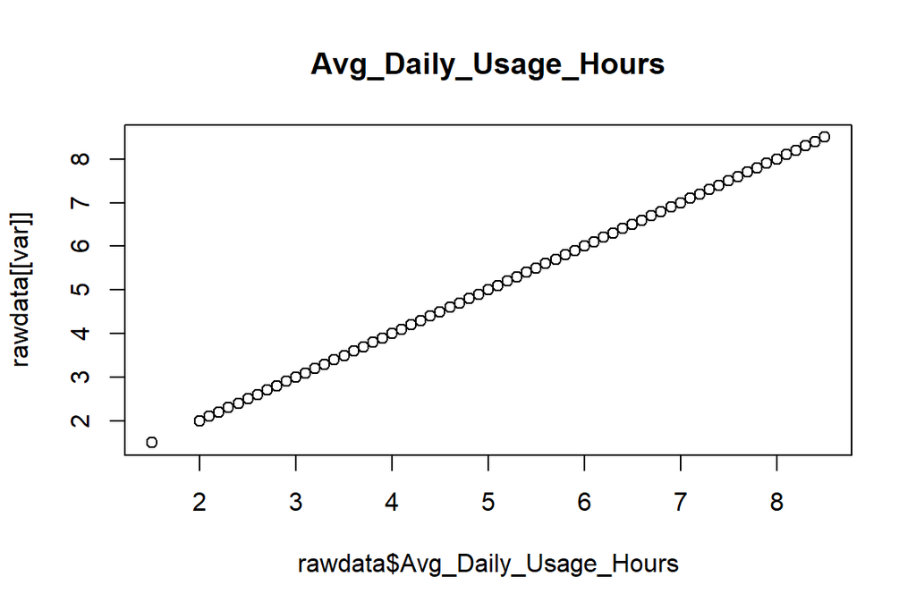

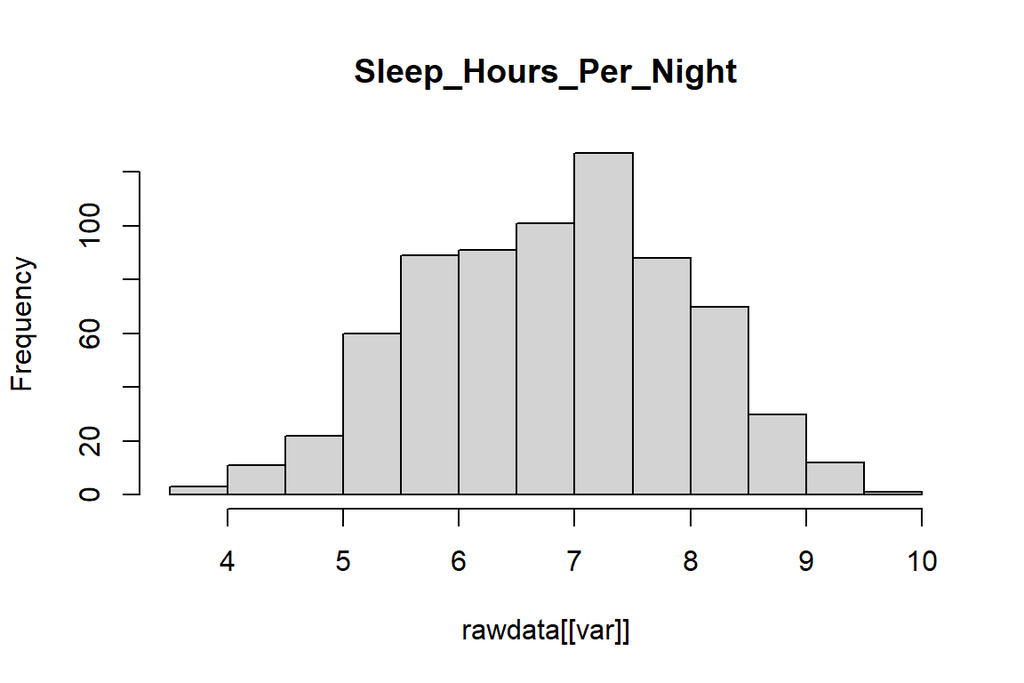

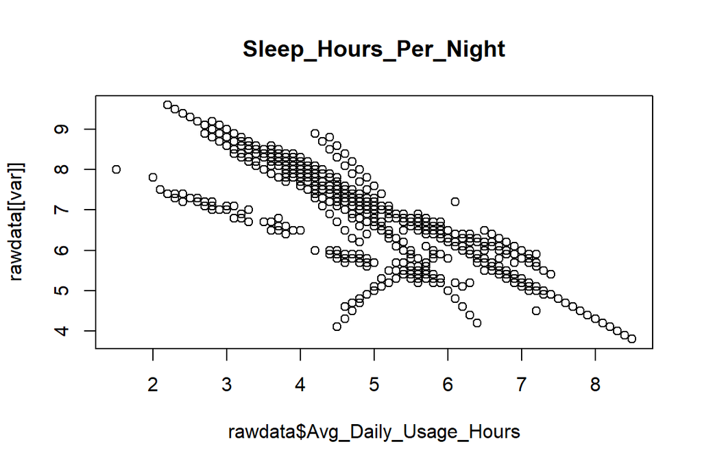

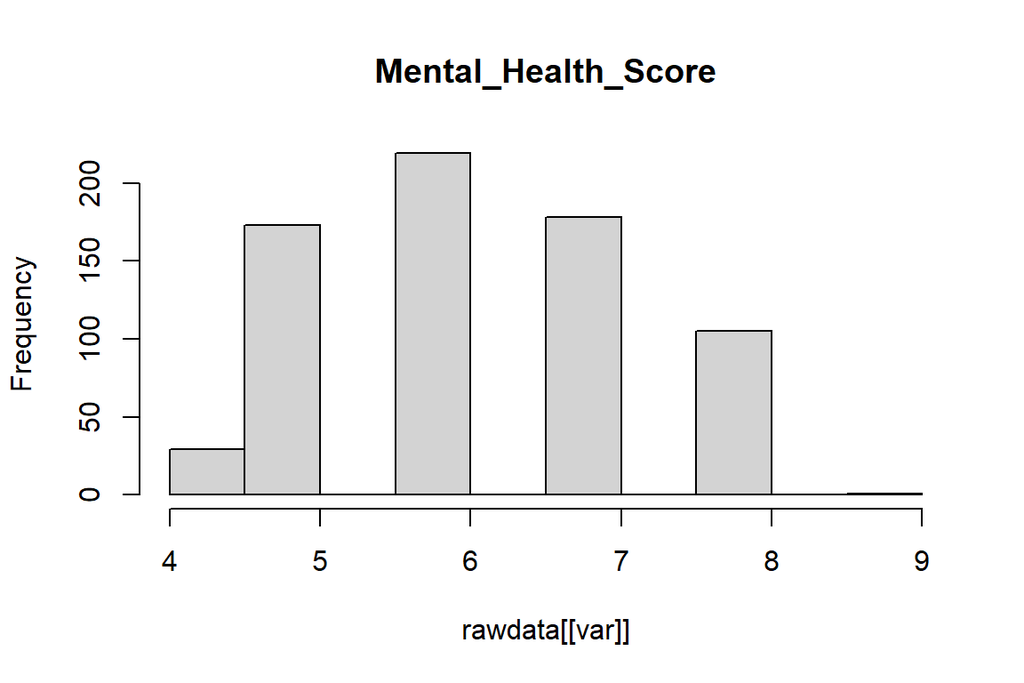

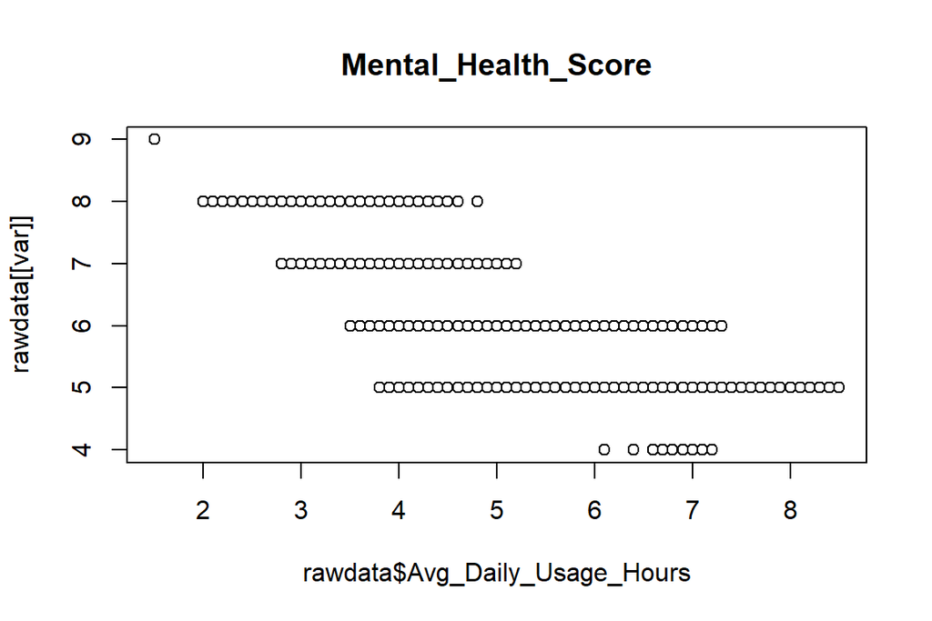

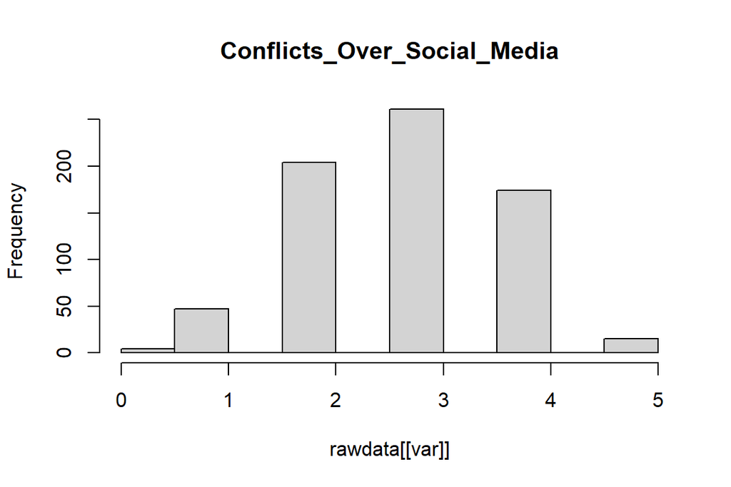

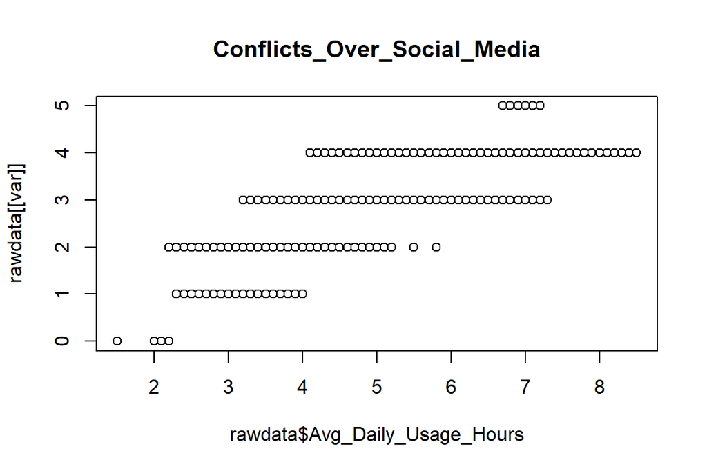

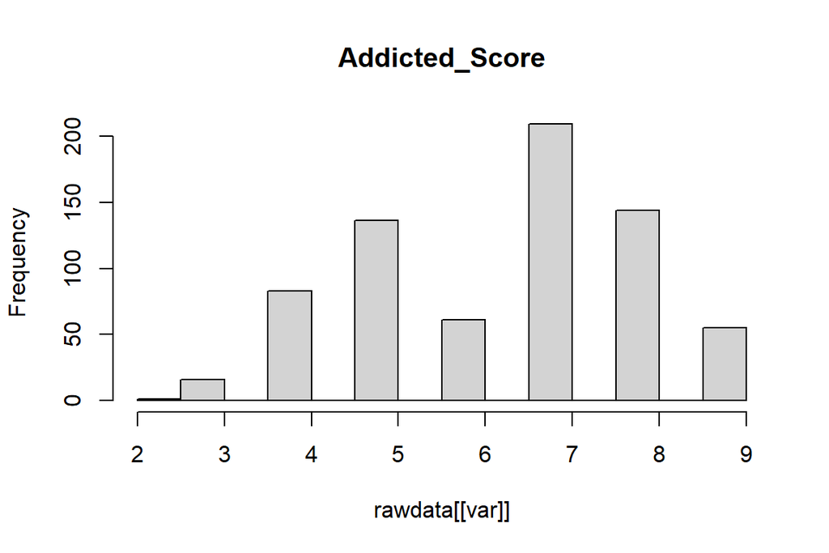

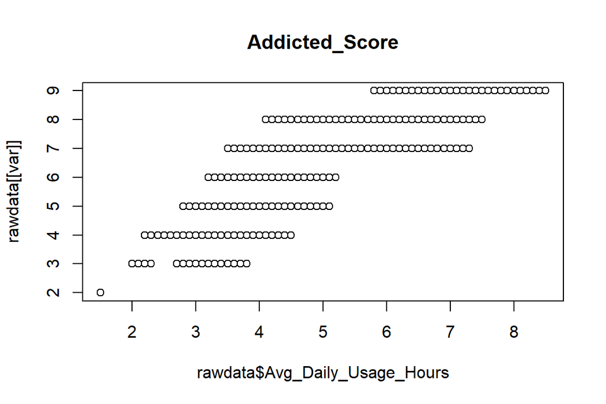

```r
##Visualizing distributions of numeric variables & their relation to daily usage

numeric_vars <- names(rawdata)[sapply(rawdata, is.numeric)]

for (var in numeric_vars) {
  hist(rawdata[[var]],
       main = var)
  plot(rawdata$Avg_Daily_Usage_Hours, rawdata[[var]],  main = var)
}
```

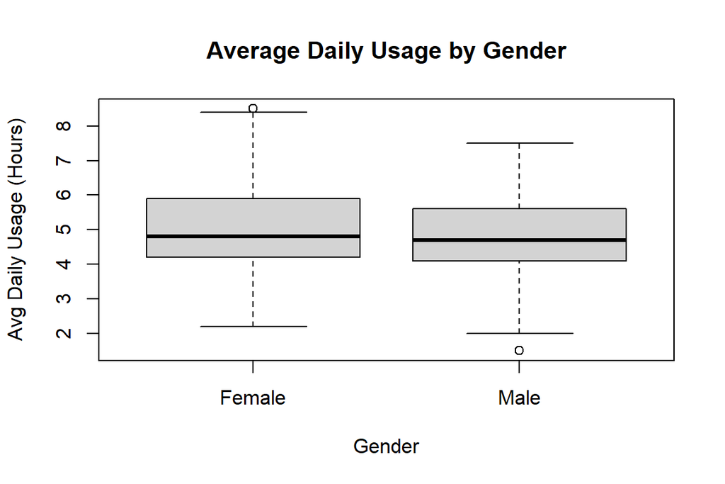

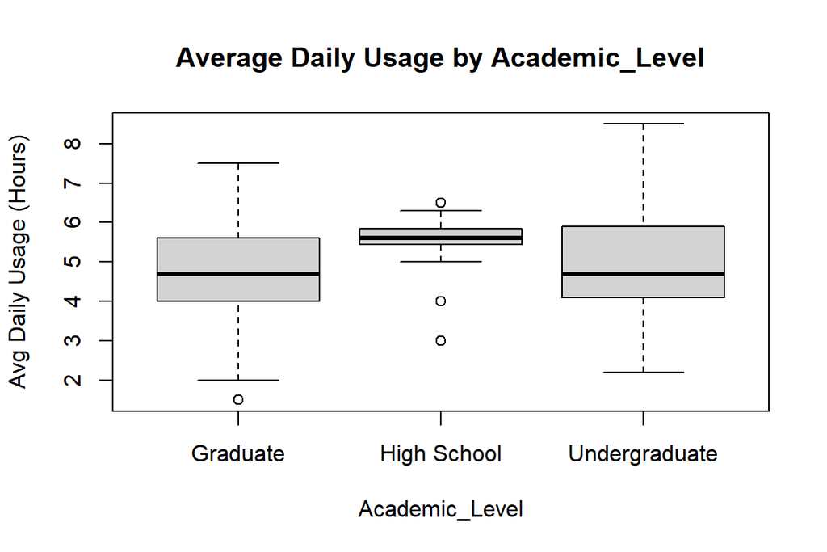

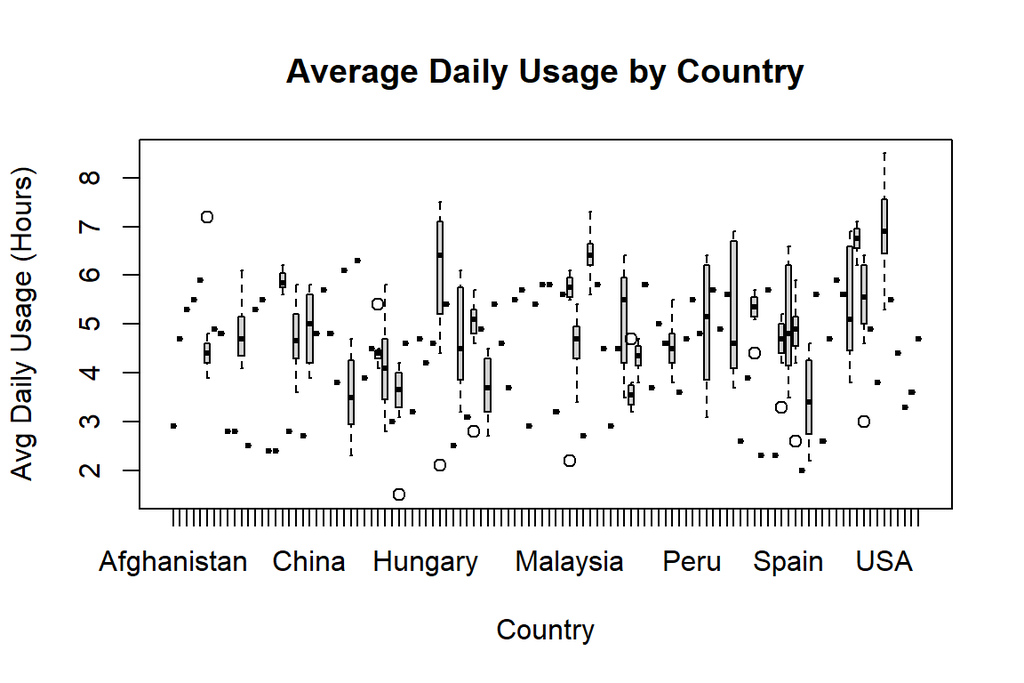

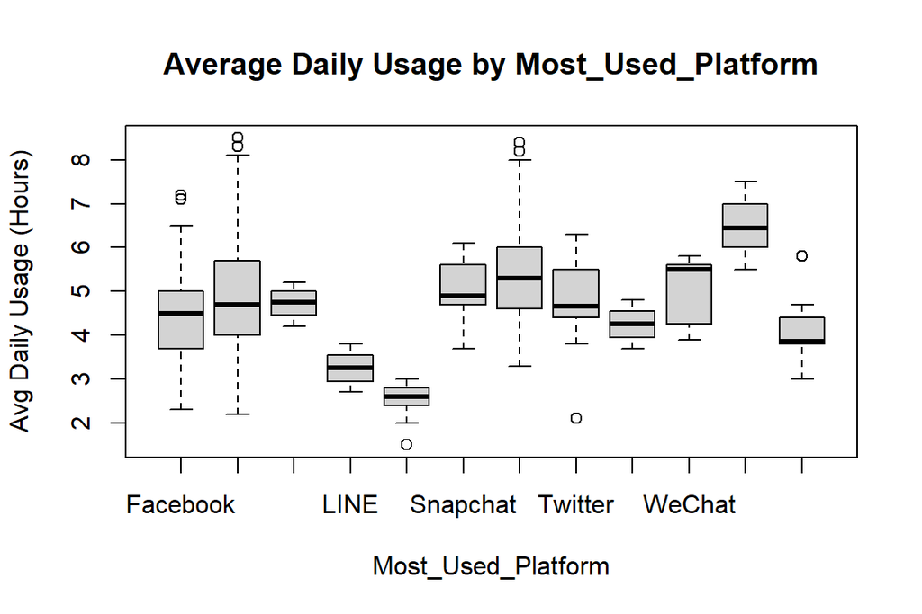

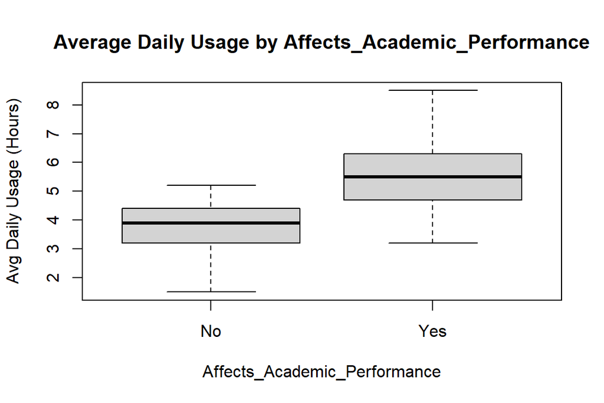

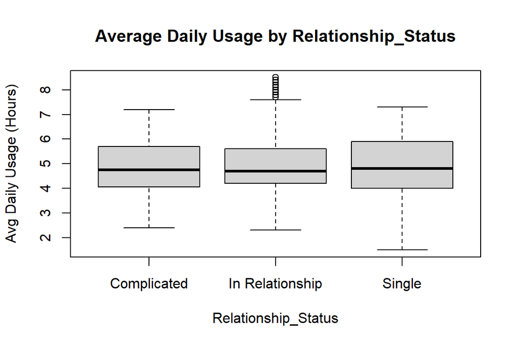

```r
#Sleep hours per night looks abnormal, but not sure what to do. No crazy outliers

##Visualizing relationships of categorical variables to daily usage

cat_vars <- names(rawdata)[sapply(rawdata, function(x) !is.numeric(x) & !is.logical(x))]

# Loop through categorical variables and create boxplots
for (var in cat_vars) {
  boxplot(rawdata$Avg_Daily_Usage_Hours ~ rawdata[[var]],
          main = paste("Average Daily Usage by", var),
          ylab = "Avg Daily Usage (Hours)",
          xlab = var)
}
```

```r
#Categorical variables seem to vary in their likely importance.
```

## Fitting A Linear Model

Now I will fit a linear model to identify what strategies may be appropriate for linear regression using this dataset.

I will **verify regression assumptions** such as **linearity, normality, homoscedasticity, independence,** and **multicollinearity.** I will also **address any assumption violations and corrections** necessary. The first model shows that there are likely significant relationships to be found between our predictor variables and daily usage hours. However, there is evidence for multicollinearity, non-independence, and non-normality, which I initially address by removing addicted score since it is likely too correlated with daily usage hours to provide valuable inference for the other variables.

```r
##First we will fit a basic linear model to compare to:

m1 <- lm(Avg_Daily_Usage_Hours ~ Age + Gender + Country + Academic_Level +
              Most_Used_Platform + Affects_Academic_Performance +
              Sleep_Hours_Per_Night + Mental_Health_Score +
              Relationship_Status + Conflicts_Over_Social_Media +
              Addicted_Score,
            data = rawdata)
summary(m1)
```

```
##
## Call:
## lm(formula = Avg_Daily_Usage_Hours ~ Age + Gender + Country +
##     Academic_Level + Most_Used_Platform + Affects_Academic_Performance +
##     Sleep_Hours_Per_Night + Mental_Health_Score + Relationship_Status +
##     Conflicts_Over_Social_Media + Addicted_Score, data = rawdata)
##
## Residuals:
##     Min      1Q  Median      3Q     Max
## -1.6605 -0.1329  0.0000  0.1771  1.1684
##
## Coefficients:
##                                    Estimate Std. Error t value Pr(>|t|)
## (Intercept)                         6.55450    0.94206   6.958 9.48e-12 ***
## Age                                 0.07925    0.02110   3.756 0.000190 ***
## GenderMale                         -0.02691    0.04630  -0.581 0.561286
## CountryAlbania                      0.17013    0.50619   0.336 0.736921
## CountryAndorra                     -0.35742    0.56761  -0.630 0.529140
## CountryArgentina                   -0.21576    0.56647  -0.381 0.703422
## CountryArmenia                      0.48366    0.52796   0.916 0.360009
## CountryAustralia                   -0.41878    0.41243  -1.015 0.310354
## CountryAustria                      0.18406    0.50490   0.365 0.715584
## CountryAzerbaijan                  -0.57338    0.53240  -1.077 0.281949
## CountryBahamas                     -0.16807    0.50428  -0.333 0.739035
## CountryBahrain                      0.74470    0.47735   1.560 0.119296
## CountryBangladesh                  -0.45092    0.41635  -1.083 0.279251
## CountryBelarus                     -0.24975    0.50178  -0.498 0.618870
## CountryBelgium                     -0.28816    0.56621  -0.509 0.611005
## CountryBhutan                       0.01100    0.58993   0.019 0.985135
## CountryBolivia                      0.27693    0.47703   0.581 0.561793
## CountryBosnia                       0.48378    0.47539   1.018 0.309268
## CountryBrazil                       0.58727    0.43632   1.346 0.178850
## CountryBulgaria                     0.05572    0.50212   0.111 0.911686
## CountryCanada                       0.47513    0.41290   1.151 0.250333
## CountryChile                        0.56546    0.47785   1.183 0.237165
## CountryChina                       -0.28151    0.50679  -0.555 0.578790
## CountryColombia                    -0.62186    0.53100  -1.171 0.242038
## CountryCosta Rica                  -0.20730    0.56629  -0.366 0.714455
## CountryCroatia                     -0.88105    0.53290  -1.653 0.098817 .
## CountryCyprus                      -0.94745    0.50541  -1.875 0.061357 .
```

[output cut: 96 more lines]

```
## Most_Used_PlatformWhatsApp          0.56050    0.08209   6.828 2.20e-11 ***
## Most_Used_PlatformYouTube          -1.41631    0.19931  -7.106 3.57e-12 ***
## Affects_Academic_PerformanceYes    -1.32525    0.10103 -13.118  < 2e-16 ***
## Sleep_Hours_Per_Night              -0.63804    0.02528 -25.240  < 2e-16 ***
## Mental_Health_Score                -0.19046    0.05600  -3.401 0.000717 ***
## Relationship_StatusIn Relationship  0.76973    0.16998   4.528 7.23e-06 ***
## Relationship_StatusSingle           0.77970    0.16879   4.619 4.76e-06 ***
## Conflicts_Over_Social_Media         0.44077    0.05756   7.657 8.12e-14 ***
## Addicted_Score                      0.17658    0.05892   2.997 0.002846 **
## ---
## Signif. codes:  0 '***' 0.001 '**' 0.01 '*' 0.05 '.' 0.1 ' ' 1
##
## Residual standard error: 0.3343 on 573 degrees of freedom
## Multiple R-squared:  0.9425, Adjusted R-squared:  0.9293
## F-statistic: 71.66 on 131 and 573 DF,  p-value: < 2.2e-16
```

```r
##Checking for multicolinearity | FAIL (Addicted Score)
vif(m1)
```

```
##                                      GVIF  Df GVIF^(1/(2*Df))
## Age                          5.489220e+00   1        2.342909
## Gender                       3.380959e+00   1        1.838739
## Country                      9.414904e+09 109        1.111096
## Academic_Level               5.081582e+01   2        2.669929
## Most_Used_Platform           4.137307e+06  11        1.998757
## Affects_Academic_Performance 1.478953e+01   1        3.845716
## Sleep_Hours_Per_Night        5.112037e+00   1        2.260982
## Mental_Health_Score          2.412141e+01   1        4.911355
## Relationship_Status          2.794661e+01   2        2.299229
## Conflicts_Over_Social_Media  1.915576e+01   1        4.376729
## Addicted_Score               5.509881e+01   1        7.422857
```

```r
#Checking for residual independence | FAIL
dwtest(m1)
```

```
##
##  Durbin-Watson test
##
## data:  m1
## DW = 1.8465, p-value = 0.04425
## alternative hypothesis: true autocorrelation is greater than 0
```

[figure not shown]

```r
## Checking for Normality of residuals | FAIL

qqnorm(m1$residuals)
qqline(m1$residuals, col = "red")
```

```r
##Data cleaning: I remove Addicted Score since it has the highest VIF value and there are other variables likley capture what is happening within that variable well.

cleandata<- rawdata%>%
  select(!Addicted_Score)
```

In the second model, I see that linearity, and normality are still really out of line. I then remove sleep hours per night because it had a noisy distribution earlier, and I hope that the normality and linearity would improve with it removed.

```r
#rerun the model to see if multicolinearity improved
m2 <- lm(Avg_Daily_Usage_Hours ~ Age + Gender + Country + Academic_Level +
              Most_Used_Platform + Affects_Academic_Performance +
              Sleep_Hours_Per_Night + Mental_Health_Score +
              Relationship_Status + Conflicts_Over_Social_Media,
            data = cleandata)
summary(m2)
```

```
##
## Call:
## lm(formula = Avg_Daily_Usage_Hours ~ Age + Gender + Country +
##     Academic_Level + Most_Used_Platform + Affects_Academic_Performance +
##     Sleep_Hours_Per_Night + Mental_Health_Score + Relationship_Status +
##     Conflicts_Over_Social_Media, data = cleandata)
##
## Residuals:
##     Min      1Q  Median      3Q     Max
## -1.7250 -0.1305  0.0000  0.1642  1.2469
##
## Coefficients:
##                                     Estimate Std. Error t value Pr(>|t|)
## (Intercept)                         8.334296   0.736347  11.318  < 2e-16 ***
## Age                                 0.073426   0.021152   3.471 0.000557 ***
## GenderMale                         -0.031029   0.046600  -0.666 0.505764
## CountryAlbania                      0.134774   0.509558   0.264 0.791496
## CountryAndorra                     -0.513820   0.569118  -0.903 0.366992
## CountryArgentina                   -0.356790   0.568420  -0.628 0.530459
## CountryArmenia                      0.534615   0.531345   1.006 0.314765
## CountryAustralia                   -0.473057   0.414890  -1.140 0.254679
## CountryAustria                      0.170251   0.508378   0.335 0.737830
## CountryAzerbaijan                  -0.615492   0.535907  -1.149 0.251238
## CountryBahamas                     -0.190394   0.507720  -0.375 0.707801
## CountryBahrain                      0.749181   0.480658   1.559 0.119629
## CountryBangladesh                  -0.495486   0.418967  -1.183 0.237442
## CountryBelarus                     -0.260946   0.505241  -0.516 0.605720
## CountryBelgium                     -0.424511   0.568291  -0.747 0.455372
## CountryBhutan                      -0.176779   0.590655  -0.299 0.764825
## CountryBolivia                      0.299499   0.480278   0.624 0.533141
## CountryBosnia                       0.505204   0.478626   1.056 0.291628
## CountryBrazil                       0.619072   0.439214   1.410 0.159229
## CountryBulgaria                     0.062223   0.505591   0.123 0.902094
## CountryCanada                       0.462849   0.415744   1.113 0.266044
## CountryChile                        0.575756   0.481146   1.197 0.231943
## CountryChina                       -0.306372   0.510238  -0.600 0.548443
## CountryColombia                    -0.663620   0.534492  -1.242 0.214895
## CountryCosta Rica                  -0.324518   0.568851  -0.570 0.568575
## CountryCroatia                     -0.891756   0.536584  -1.662 0.097076 .
## CountryCyprus                      -0.833889   0.507482  -1.643 0.100891
```

[output cut: 95 more lines]

```
## Most_Used_PlatformWeChat            0.610821   0.390749   1.563 0.118555
## Most_Used_PlatformWhatsApp          0.519379   0.081497   6.373 3.81e-10 ***
## Most_Used_PlatformYouTube          -1.434764   0.200599  -7.152 2.61e-12 ***
## Affects_Academic_PerformanceYes    -1.226868   0.096208 -12.752  < 2e-16 ***
## Sleep_Hours_Per_Night              -0.661396   0.024215 -27.313  < 2e-16 ***
## Mental_Health_Score                -0.291256   0.045079  -6.461 2.22e-10 ***
## Relationship_StatusIn Relationship  0.800010   0.170852   4.682 3.54e-06 ***
## Relationship_StatusSingle           0.784127   0.169955   4.614 4.88e-06 ***
## Conflicts_Over_Social_Media         0.522815   0.050984  10.254  < 2e-16 ***
## ---
## Signif. codes:  0 '***' 0.001 '**' 0.01 '*' 0.05 '.' 0.1 ' ' 1
##
## Residual standard error: 0.3366 on 574 degrees of freedom
## Multiple R-squared:  0.9416, Adjusted R-squared:  0.9283
## F-statistic: 71.15 on 130 and 574 DF,  p-value: < 2.2e-16
```

```r
##Checking for residual independence | PASS

dwtest(m2)
```

```
##
##  Durbin-Watson test
##
## data:  m2
## DW = 1.8663, p-value = 0.07137
## alternative hypothesis: true autocorrelation is greater than 0
```

```r
#collinearity? |PASS
vif(m2)
```

```
##                                      GVIF  Df GVIF^(1/(2*Df))
## Age                          5.442682e+00   1        2.332956
## Gender                       3.377983e+00   1        1.837929
## Country                      5.044384e+09 109        1.107920
## Academic_Level               4.907122e+01   2        2.646712
## Most_Used_Platform           3.669376e+06  11        1.987882
## Affects_Academic_Performance 1.322811e+01   1        3.637047
## Sleep_Hours_Per_Night        4.626378e+00   1        2.150902
## Mental_Health_Score          1.541913e+01   1        3.926720
## Relationship_Status          2.707791e+01   2        2.281150
## Conflicts_Over_Social_Media  1.482218e+01   1        3.849959
```

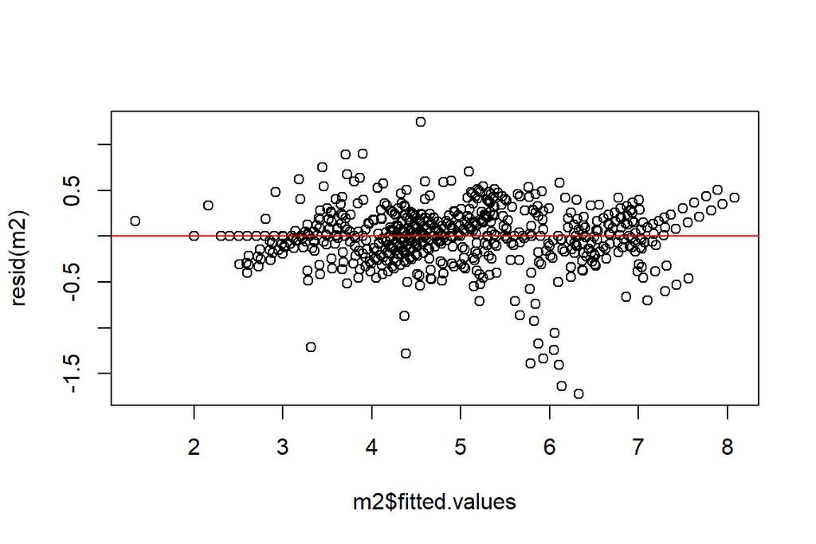

```r
#Linearity | FAIL, angled and vertical is not good, even for Discrete variables

plot(m2$fitted.values, resid(m2))
abline(h = 0, col = "red")
```

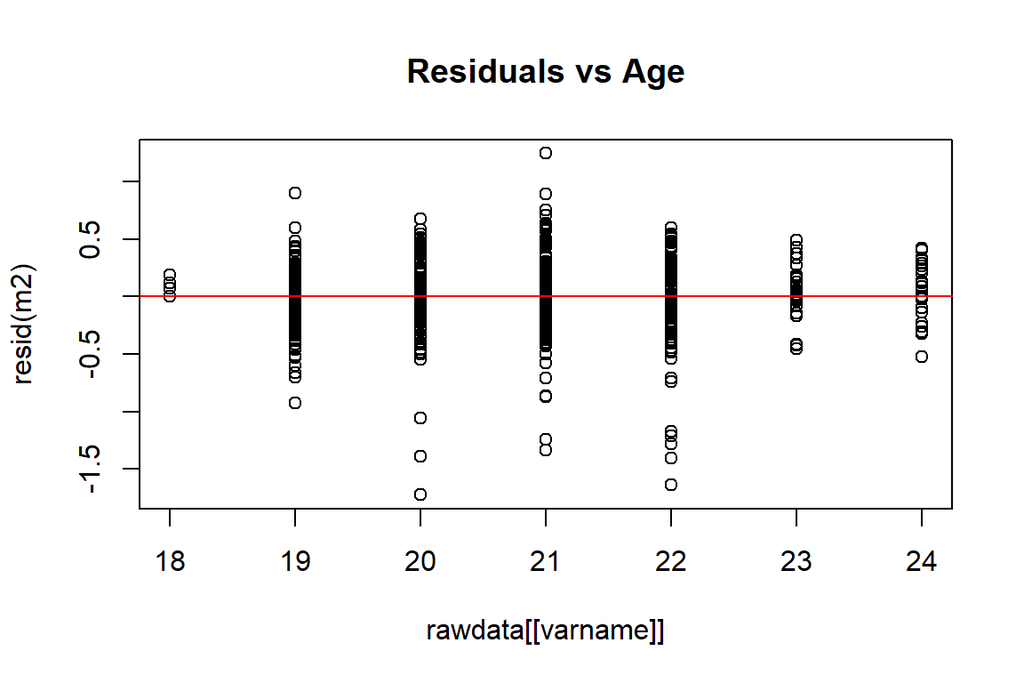

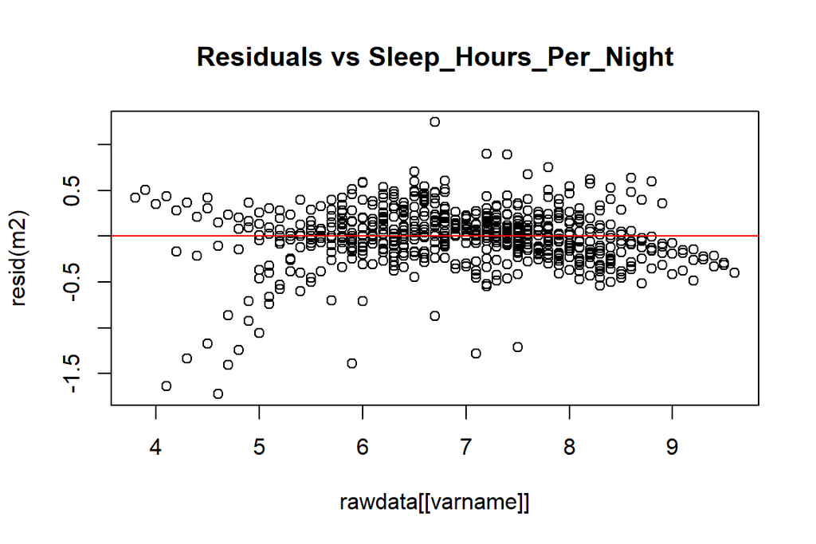

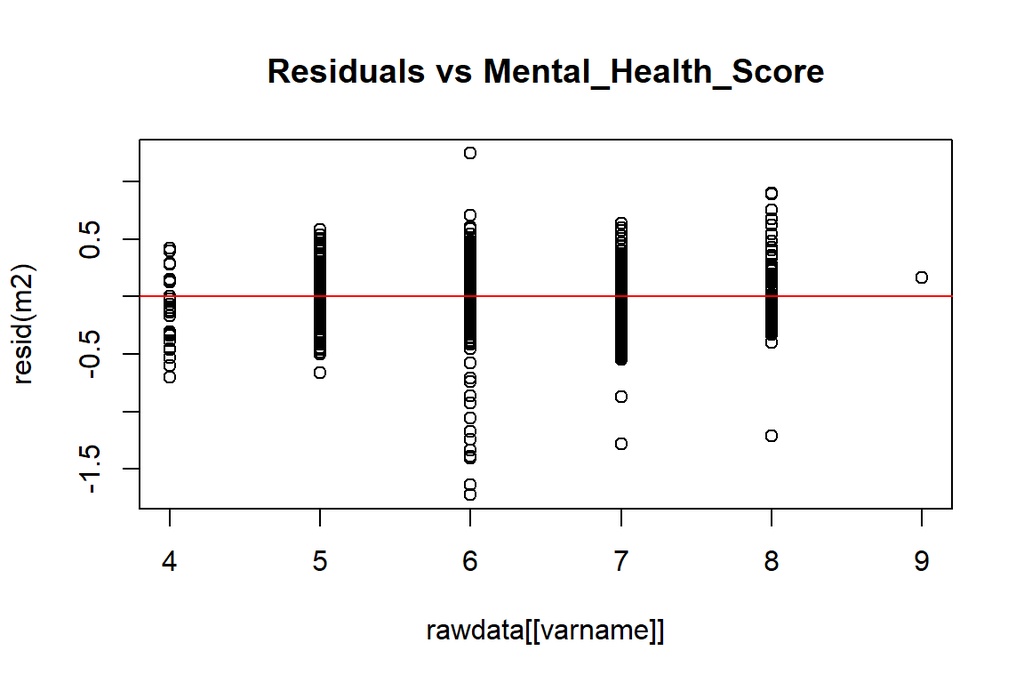

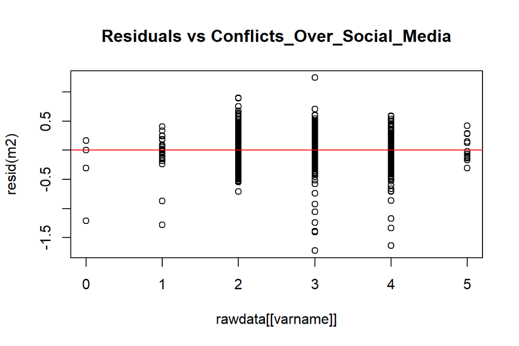

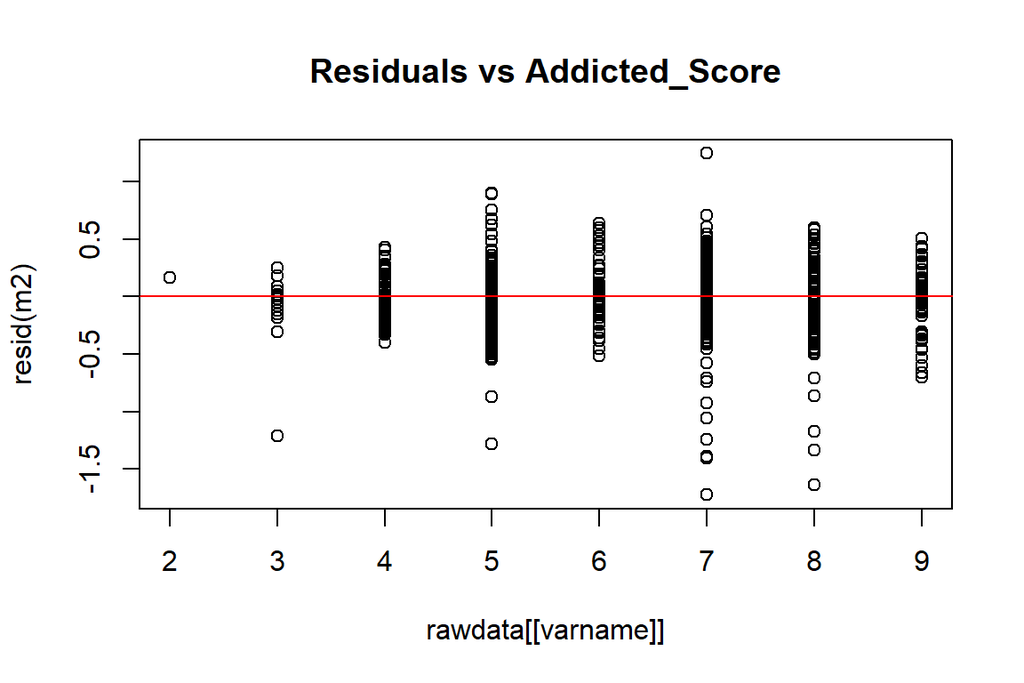

```r
# Loop through all predictors
for (varname in numeric_vars) {

  if (varname != "Avg_Daily_Usage_Hours") {
    plot(rawdata[[varname]], resid(m2),
         main = paste("Residuals vs", varname))
    abline(h = 0, col = "red")
  }
}
```

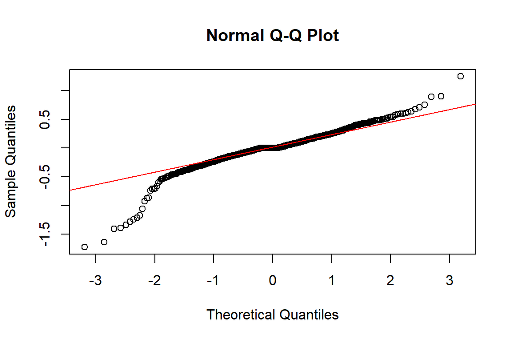

```r
## Checking for Normality of residuals | FAIL

qqnorm(m2$residuals)
qqline(m2$residuals, col = "red")
```

```r
##Removing Sleep_hours_per_night since the residual plot does not indicate a straightforward transformation to fix it.
cleandata<- cleandata%>%
  select(!Sleep_Hours_Per_Night)
```

The removal of sleep hours fixes the skew in the residuals, but the vertical pattern persists. This is likely due to the discrete variables I have, which I believe does not violate linearity assumptions if the discrete variables represent chance at consistent increments as the ones I include do. If the discrete variables were factors, that would be a worse fit.

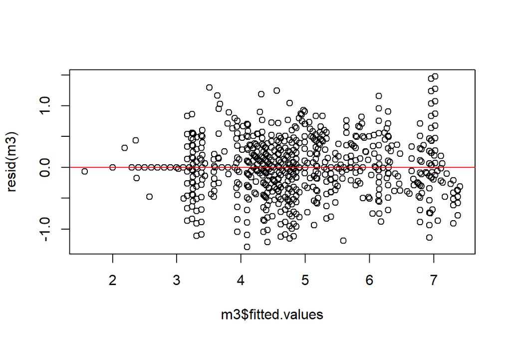

```r
m3 <- lm(Avg_Daily_Usage_Hours ~ Age + Gender + Country + Academic_Level +
              Most_Used_Platform + Affects_Academic_Performance + Mental_Health_Score + Relationship_Status + Conflicts_Over_Social_Media,
            data = cleandata)

##Checking residuals | PASS: Better but still vertical. perhaps that is just due to the Discrete variables I have

plot(m3$fitted.values, resid(m3))
abline(h = 0, col = "red")
```

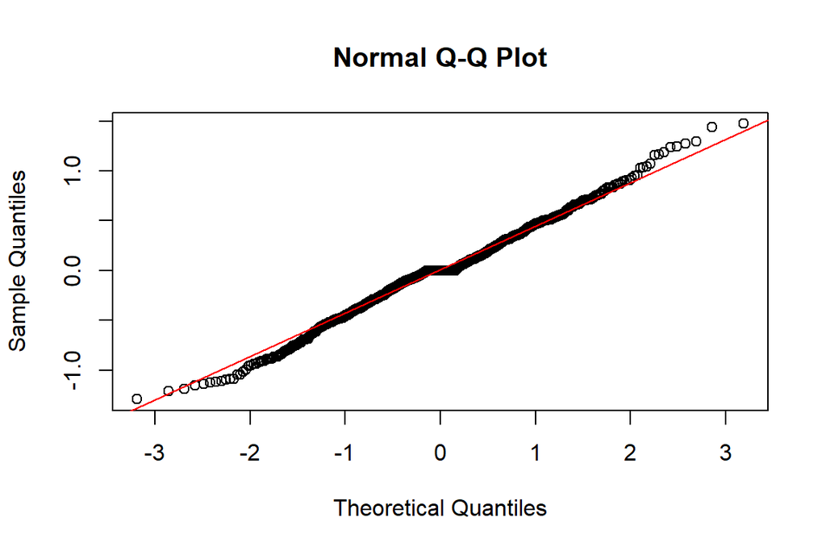

```r
## Checking for Normality of residuals | PASS

qqnorm(m3$residuals)
qqline(m3$residuals, col = "red")
```

```r
##Checking for multicolinearity | PASS
vif(m3)
```

```
##                                      GVIF  Df GVIF^(1/(2*Df))
## Age                          5.354376e+00   1        2.313952
## Gender                       3.377437e+00   1        1.837780
## Country                      2.941584e+09 109        1.105182
## Academic_Level               4.812217e+01   2        2.633821
## Most_Used_Platform           3.401607e+06  11        1.981047
## Affects_Academic_Performance 1.223187e+01   1        3.497409
## Mental_Health_Score          1.467273e+01   1        3.830500
## Relationship_Status          2.586398e+01   2        2.255142
## Conflicts_Over_Social_Media  1.479217e+01   1        3.846058
```

```r
#Checking for residual independence | FAIL
dwtest(m3)
```

```
##
##  Durbin-Watson test
##
## data:  m3
## DW = 1.5502, p-value = 4.823e-08
## alternative hypothesis: true autocorrelation is greater than 0
```

```r
## Switching to a mixed effects model to see if country and mental health score are random effects.
```

## I switch to a mixed-effects model.

I switch to mixed effects to see if it improves the non-independence of the observations. I stick with a mixed-effects model. I put country as a random effect, and tried various other combinations of variables to potentially address non-independence, but none improved the durbin watson test values enough to fail to reject the null hypothesis of independence. Mental_Health_Score as a random slope improved model performance, but worsened the tails on the qq plot, so it was removed as a random effector. All other assumptions are met. I decide to use the mixed effects model with bootstrapped confidence intervals since the mixed effects model minimized the BIC in the model iterations I had with fewer confidence intervals, and I wanted to increase the chance of seeing significant relationships since bootstrapped confidence intervals can be heavily conservative.

```r
m4 <- lmer(Avg_Daily_Usage_Hours ~ Age + Gender + Academic_Level +
           Most_Used_Platform + Affects_Academic_Performance +
           Mental_Health_Score + Relationship_Status +
           Conflicts_Over_Social_Media +
           (1 | Country),
           control = lmerControl(optimizer = "bobyqa"),
           data = cleandata)
summary(m4)
```

```
## Linear mixed model fit by REML ['lmerMod']
## Formula:
## Avg_Daily_Usage_Hours ~ Age + Gender + Academic_Level + Most_Used_Platform +
##     Affects_Academic_Performance + Mental_Health_Score + Relationship_Status +
##     Conflicts_Over_Social_Media + (1 | Country)
##    Data: cleandata
## Control: lmerControl(optimizer = "bobyqa")
##
## REML criterion at convergence: 1168.2
##
## Scaled residuals:
##      Min       1Q   Median       3Q      Max
## -2.56152 -0.59444 -0.00492  0.62637  3.11817
##
## Random effects:
##  Groups   Name        Variance Std.Dev.
##  Country  (Intercept) 0.1316   0.3628
##  Residual             0.2504   0.5004
## Number of obs: 705, groups:  Country, 110
##
## Fixed effects:
##                                    Estimate Std. Error t value
## (Intercept)                         3.75608    0.86281   4.353
## Age                                 0.12154    0.02927   4.152
## GenderMale                         -0.07215    0.06157  -1.172
## Academic_LevelHigh School           0.26057    0.17825   1.462
## Academic_LevelUndergraduate         0.35430    0.09480   3.737
## Most_Used_PlatformInstagram         0.03313    0.08173   0.405
## Most_Used_PlatformKakaoTalk        -0.18687    0.34666  -0.539
## Most_Used_PlatformLINE             -0.19982    0.24503  -0.815
## Most_Used_PlatformLinkedIn         -0.55649    0.16013  -3.475
## Most_Used_PlatformSnapchat         -0.09938    0.19143  -0.519
## Most_Used_PlatformTikTok           -0.12353    0.08490  -1.455
## Most_Used_PlatformTwitter           0.16315    0.12342   1.322
## Most_Used_PlatformVKontakte         0.28634    0.23096   1.240
## Most_Used_PlatformWeChat            0.55130    0.33204   1.660
## Most_Used_PlatformWhatsApp          0.73598    0.11428   6.440
## Most_Used_PlatformYouTube          -0.31787    0.20480  -1.552
## Affects_Academic_PerformanceYes    -0.33754    0.11914  -2.833
## Mental_Health_Score                -0.51711    0.05822  -8.882
## Relationship_StatusIn Relationship  0.25891    0.12592   2.056
## Relationship_StatusSingle           0.09234    0.12130   0.761
## Conflicts_Over_Social_Media         0.57440    0.06654   8.632
```

```
##
## Correlation matrix not shown by default, as p = 21 > 12.
## Use print(x, correlation=TRUE)  or
##     vcov(x)        if you need it
```

```r
##Comparing performance between m3 and m4 | the mixed effects model (m4) has a substantially lower BIC.
Anova(m3)
```

```
## Anova Table (Type II tests)
##
## Response: Avg_Daily_Usage_Hours
##                               Sum Sq  Df F value    Pr(>F)
## Age                            5.564   1 21.3899 4.633e-06 ***
## Gender                         0.116   1  0.4474 0.5038642
## Country                      120.104 109  4.2363 < 2.2e-16 ***
## Academic_Level                 4.319   2  8.3022 0.0002789 ***
## Most_Used_Platform            17.240  11  6.0255 2.330e-09 ***
## Affects_Academic_Performance   3.386   1 13.0168 0.0003356 ***
## Mental_Health_Score           18.516   1 71.1860 2.641e-16 ***
## Relationship_Status            4.436   2  8.5280 0.0002240 ***
## Conflicts_Over_Social_Media   14.972   1 57.5606 1.327e-13 ***
## Residuals                    149.560 575
## ---
## Signif. codes:  0 '***' 0.001 '**' 0.01 '*' 0.05 '.' 0.1 ' ' 1
```

```r
Anova(m4)
```

```
## Analysis of Deviance Table (Type II Wald chisquare tests)
##
## Response: Avg_Daily_Usage_Hours
##                                Chisq Df Pr(>Chisq)
## Age                          17.2430  1  3.289e-05 ***
## Gender                        1.3735  1  0.2412087
## Academic_Level               15.4411  2  0.0004436 ***
## Most_Used_Platform           85.9342 11  1.039e-13 ***
## Affects_Academic_Performance  8.0265  1  0.0046097 **
## Mental_Health_Score          78.8898  1  < 2.2e-16 ***
## Relationship_Status           8.9863  2  0.0111855 *
## Conflicts_Over_Social_Media  74.5082  1  < 2.2e-16 ***
## ---
## Signif. codes:  0 '***' 0.001 '**' 0.01 '*' 0.05 '.' 0.1 ' ' 1
```

```r
BIC(m3,m4)
```

```
##     df      BIC
## m3 131 1766.726
## m4  23 1319.001
```

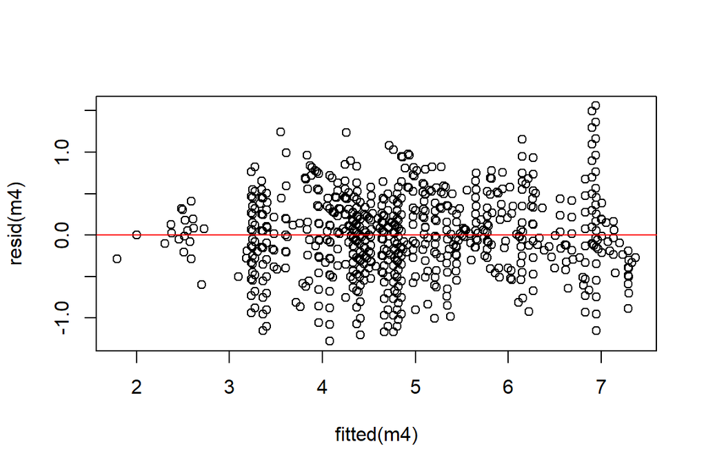

```r
## Checking for Normality and linearity of residuals | Normality looks ok, with some caveats. Discrete variables are likely causing the pattern we see, but I feel comfortable that this meets the normality assumption given how big the dataset is and that the Discrete variables we have are equally spaced and best kept as discrete. Linearity is good, with random scatter around zero.

plot(fitted(m4), resid(m4))
abline(h = 0, col = "red")
```

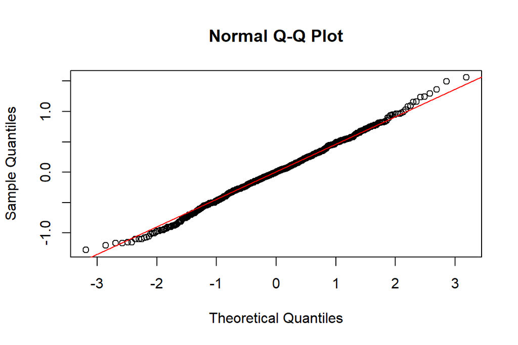

```r
qqnorm(resid(m4))
qqline(resid(m4), col = "red")
```

```r
##Checking for multicolinearity | PASS
vif(m4)
```

```
##                                  GVIF Df GVIF^(1/(2*Df))
## Age                          3.384233  1        1.839628
## Gender                       1.673278  1        1.293552
## Academic_Level               4.630161  2        1.466895
## Most_Used_Platform           4.424583 11        1.069936
## Affects_Academic_Performance 3.970900  1        1.992712
## Mental_Health_Score          5.092777  1        2.256718
## Relationship_Status          1.345331  2        1.076979
## Conflicts_Over_Social_Media  6.279471  1        2.505887
```

```r
## Checking Homoscedasticity | PASS
bp_model <- lm(resid(m4) ~ fitted(m4))
summary(bp_model)
```

```
##
## Call:
## lm(formula = resid(m4) ~ fitted(m4))
##
## Residuals:
##      Min       1Q   Median       3Q      Max
## -1.27024 -0.29859 -0.00004  0.31327  1.53256
##
## Coefficients:
##             Estimate Std. Error t value Pr(>|t|)
## (Intercept) -0.06737    0.07865  -0.857    0.392
## fitted(m4)   0.01370    0.01557   0.880    0.379
##
## Residual standard error: 0.4746 on 703 degrees of freedom
## Multiple R-squared:  0.001099,   Adjusted R-squared:  -0.0003216
## F-statistic: 0.7737 on 1 and 703 DF,  p-value: 0.3794
```

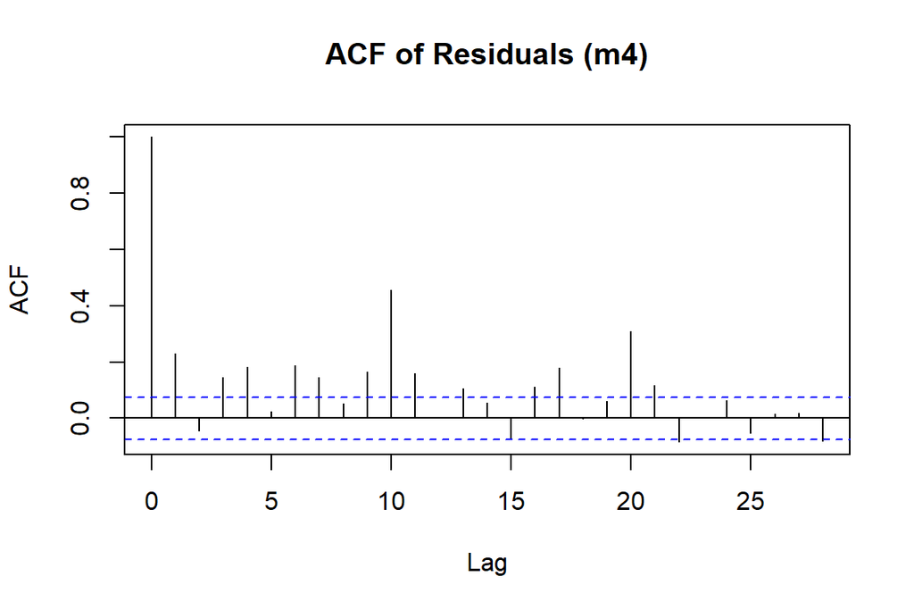

```r
#Checking for residual independence | FAIL There is still autocorrelation.
acf(resid(m4), main = "ACF of Residuals (m4)")
```

```r
#After trying various combinations of random and fixed effects after this point, I was unable to address the non-independence in the residuals. This model meets assumptions for linearity, normality, multicollinearity, and homoscedasticity, but fails to meet the assumptions for independence of observations. Therefore I will be conducting hypothesis tests and constructing confidence intervals using bootstrapping.
```